# R Notebook

# Final project

**Team**: Oleksii Mytnyk, Yaroslav Klym, Shevchenko Ivan

```r
require(BSDA)
library(BSDA)
require(EnvStats)
library(EnvStats)
library(dplyr)
library(tidyr)
```

## Sample data description

We decided to choose to analyze Steam PC game dataset.

```r
data = read.csv("games_data.csv")
data
```

| id | title | release_date | developer | publisher | genres | multiplayer_or_singleplayer | price | dc_price | overall_review | detailed_review | reviews | percent_positive | win_support | mac_support | lin_support |
| --- | --- | --- | --- | --- | --- | --- | --- | --- | --- | --- | --- | --- | --- | --- | --- |
| 0 | Counter-Strike: Global Offensive | 2012-08-21 | Valve;Hidden Path Entertainment | Valve | Action;Free to Play | Multi-player;Steam Achievements;Full controller support;Steam Trading Cards;Steam Workshop;In-App Purchases;Valve Anti-Cheat enabled;Stats | Free to play | Free to play | Positive | Very Positive | 6774812 | 88% | 1 | 1 | 1 |
| 1 | Dota 2 | 2013-07-09 | Valve | Valve | Action;Free to Play;Strategy | Multi-player;Co-op;Steam Trading Cards;Steam Workshop;SteamVR Collectibles;In-App Purchases;Valve Anti-Cheat enabled | Free to play | Free to play | Positive | Very Positive | 1885261 | 82% | 1 | 1 | 1 |
| 2 | Warhammer 40,000: Darktide |  |  |  |  |  | 2,199 | 2,199 | Positive | Mostly Positive | 26092 | 72% | 1 | 0 | 0 |
| 3 | Call of Duty\xae: Modern Warfare\xae II |  |  |  |  |  | 4,999 | 4,999 | Mixed | Mixed | 215969 | 64% | 1 | 0 | 0 |
| 4 | Apex Legends\x99 |  |  |  |  |  | Free to play | Free to play | Positive | Very Positive | 539297 | 85% | 1 | 0 | 0 |
| 5 | PUBG: BATTLEGROUNDS |  |  |  |  |  | Free to play | Free to play | Mixed | Mixed | 2109992 | 56% | 1 | 0 | 0 |
| 6 | NARAKA: BLADEPOINT |  |  |  |  |  | 1,199 | 1,199 | Positive | Mostly Positive | 130245 | 73% | 1 | 0 | 0 |
| 7 | Dead by Daylight | 2016-06-14 | Behaviour Digital Inc. | Behaviour Digital Inc. | Action | Multi-player;Online Multi-Player;Co-op;Online Co-op;Steam Achievements;Full controller support;Steam Trading Cards;Steam Cloud | 749 | 749 | Positive | Very Positive | 453698 | 81% | 1 | 0 | 0 |
| 8 | Warframe | 2013-03-25 | Digital Extremes | Digital Extremes | Action;Free to Play | Single-player;Multi-player;Co-op;Steam Trading Cards;In-App Purchases;Partial Controller Support | Free to play | Free to play | Positive | Very Positive | 512887 | 87% | 1 | 0 | 0 |
| 9 | War Thunder | 2013-08-15 | Gaijin Entertainment | Gaijin Entertainment | Action;Free to Play;Massively Multiplayer;Simulation | Single-player;MMO;Co-op;Cross-Platform Multiplayer;Steam Achievements;In-App Purchases;Partial Controller Support | Free to play | Free to play | Positive | Mixed | 28437 | 48% | 1 | 1 | 1 |

[output cut: 9990 more lines]

## Distribution of price

We will test dependency between price and another parameters of the game.

Here we analyze the distribution of the price of the games and testing whether it have normal distribution. We used Kolmogorov test to check it and we see that this distribution is not normal as p-value is small.

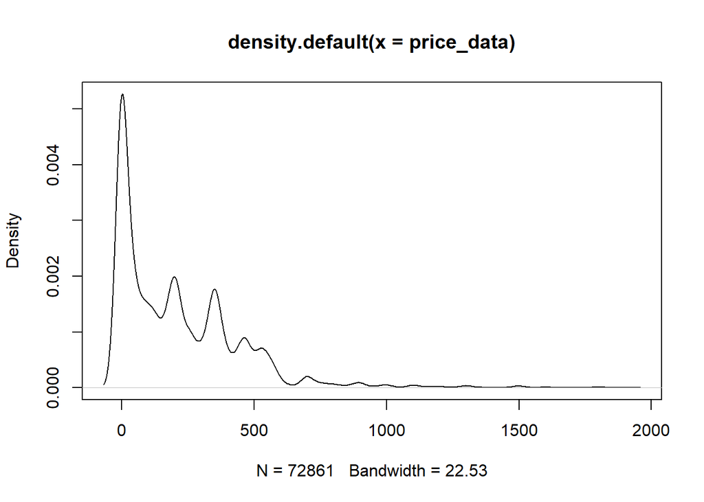

```r
data["price"][data["price"] == "Free to play"] <- 0
sample_data <- data
sample_data_with_price <- data %>% transform(price = as.numeric(gsub(",", "", price))) %>% filter(!is.na(price))
sigma2 <- 2 * sd(sample_data_with_price$price)
price_mean <- mean(sample_data_with_price$price)

price_data <- sample_data_with_price %>% filter(price <= price_mean + sigma2)
price_data <- price_data$price
plot(density(price_data))
```

```r
print(paste("Mean:", mean(price_data)))
```

```
## [1] "Mean: 210.146854970423"
```

```r
print(paste("Median:", median(price_data)))
```

```
## [1] "Median: 165"
```

```r
print(paste("Variance:", var(price_data)))
```

```
## [1] "Variance: 55204.5777196242"
```

```r
print(paste("Skewness:", skewness(price_data)))
```

```
## [1] "Skewness: 1.9027842076161"
```

```r
print(paste("Kurtosis:", kurtosis(price_data)))
```

```
## [1] "Kurtosis: 6.25211515819621"
```

```r
ks.test(price_data, "pnorm", mean(price_data), sd(price_data))
```

```
##
##  Asymptotic one-sample Kolmogorov-Smirnov test
##
## data:  price_data
## D = 0.18555, p-value < 2.2e-16
## alternative hypothesis: two-sided
```

## Hypothesis testing

### Testing price for different genres

Here we will search a dependency between genre of the game and it’s price. In order to that we take average price of all games that are from searched genre.

```r
sample_data_by_genre <- sample_data_with_price %>% separate_rows(genres, sep = ";") %>% filter(gsub(" ", "", genres) != "")
grouped_data <- sample_data_by_genre %>% group_by(genres) %>% filter(10 < n()) %>% summarise_at(vars(price), list(average_price = mean))

grouped_data[order(grouped_data$average_price), ]
```

| genres | average_price |
| --- | --- |
| Free to Play | 7.215884 |
| Massively Multiplayer | 181.821839 |
| Casual | 208.201079 |
| Gore | 233.123142 |
| Indie | 234.368696 |
| Violent | 261.428762 |
| Sexual Content | 280.606481 |
| Adventure | 281.333760 |
| Action | 282.311626 |
| Racing | 289.187858 |

[output cut: 6 more lines]

#### 1. Racing costs more than Adventure

Here we test whether racing games costs more than adventure. We use t-test, as we want to compare two means and we don’t have population variance.

```r
sample_racing <- (sample_data_by_genre %>% filter(genres == "Racing"))$price
sample_adventure <- (sample_data_by_genre %>% filter(genres == "Adventure"))$price
t.test(x = sample_racing, y = sample_adventure, alternative = "l")
```

```
##
##  Welch Two Sample t-test
##
## data:  sample_racing and sample_adventure
## t = 0.76566, df = 1023.7, p-value = 0.778
## alternative hypothesis: true difference in means is less than 0
## 95 percent confidence interval:
##      -Inf 24.74231
## sample estimates:
## mean of x mean of y
##  289.1879  281.3338
```

#### 2. Indie games are cheaper in general

Here we test whether indie games costs less than average game. We use t-test, as we want to compare two means and we don’t have population variance.

```r
sample_indie <- (sample_data_by_genre %>% filter(genres == "Indie"))$price
sample_all <- (sample_data_by_genre)$price
t.test(x = sample_indie, y = sample_all, alternative = "g")
```

```
##
##  Welch Two Sample t-test
##
## data:  sample_indie and sample_all
## t = -13.129, df = 33046, p-value = 1
## alternative hypothesis: true difference in means is greater than 0
## 95 percent confidence interval:
##  -27.39425       Inf
## sample estimates:
## mean of x mean of y
##  234.3687  258.7129
```

Since the p-value is large, **indie games are cheaper than average**.

#### 3. Racing games are expensive

Here we test whether racing games costs more than average game. We use t-test, as we want to compare two means and we don’t have population variance.

```r
sample_racing <- (sample_data_by_genre %>% filter(genres == "Racing"))$price
sample_all <- (sample_data_by_genre)$price
t.test(x = sample_racing, y = sample_all, alternative = "l")
```

```
##
##  Welch Two Sample t-test
##
## data:  sample_racing and sample_all
## t = 3.0765, df = 890.8, p-value = 0.9989
## alternative hypothesis: true difference in means is less than 0
## 95 percent confidence interval:
##      -Inf 46.78561
## sample estimates:
## mean of x mean of y
##  289.1879  258.7129
```

Since the p-value is large, **racing games are more expensive than average**.

### Testing positive reviews percentage for different developers

```r
sample_data_with_reviews <- sample_data %>% transform(percent_positive = as.numeric(gsub("%", "", percent_positive))) %>% filter(!is.na(percent_positive)) %>% filter(reviews > 1000)
sample_data_by_developer <- sample_data_with_reviews %>% filter(gsub(" ", "", developer) != "")

grouped_data <- sample_data_by_developer %>% group_by(developer) %>% filter(3 < n()) %>% summarise_at(vars(percent_positive), list(average_percent_positive = mean))

grouped_data[order(grouped_data$average_percent_positive, decreasing = T), ]
```

| developer | average_percent_positive |
| --- | --- |
| CD PROJEKT RED | 93.50000 |
| MAGES. Inc. | 93.00000 |
| Nadeo | 93.00000 |
| InvertMouse | 92.28571 |
| Dead Drop Studios LLC | 92.00000 |
| BlueEagle Productions | 91.80000 |
| NEKO WORKs | 91.71429 |
| Alientrap | 91.50000 |
| SkyGoblin | 91.50000 |
| Jean-S\xe9bastien Nouveau | 91.50000 |

[output cut: 638 more lines]

#### 4. CD PROJEKT RED has more positive reviews than Ubisoft

Here we test whether CD PROJEKT RED has more positive reviews than Ubisoft. We use t-test, as we want to compare two means and we don’t have population variance.

```r
sample_red <- (sample_data_by_developer %>% filter(developer == "CD PROJEKT RED"))$percent_positive
sample_ubisoft <- (sample_data_by_developer %>% filter(developer == "Ubisoft Montreal"))$percent_positive
t.test(x = sample_red, y = sample_ubisoft, alternative = "l")
```

```
##
##  Welch Two Sample t-test
##
## data:  sample_red and sample_ubisoft
## t = 2.2375, df = 11.719, p-value = 0.9772
## alternative hypothesis: true difference in means is less than 0
## 95 percent confidence interval:
##      -Inf 15.17199
## sample estimates:
## mean of x mean of y
##   93.5000   85.0625
```

Since the p-value is large, **CD PROJEKT RED has more positive reviews than Ubisoft**.

### Testing price for different game modes

#### 5. Testing price for single-player, multi-player

Here we will search a dependency between whether game is single-player or multi-player and it’s price. In order to that we take average price of all games that are from searched type.

```r
sample_data_by_ms <- sample_data_with_price %>% separate_rows(multiplayer_or_singleplayer, sep = ";") %>% filter(gsub(" ", "",multiplayer_or_singleplayer) != "")
grouped_data <- sample_data_by_ms %>% group_by(multiplayer_or_singleplayer) %>% filter(10 < n())  %>% summarise_at(vars(price), list(average_price = mean))

player <- c('Single-player', 'Multi-player')

grouped_data[grouped_data$multiplayer_or_singleplayer %in% player, ]
```

| multiplayer_or_singleplayer | average_price |
| --- | --- |
| Multi-player | 354.9099 |
| Single-player | 276.9586 |

#### 6. Multi-player games are more expensive then Single-player

Here we test whether multiplayer games costs more than single-player game. We use t-test, as we want to compare two means and we don’t have population variance.

```r
multi.player <- (sample_data_by_ms %>% filter(multiplayer_or_singleplayer == 'Multi-player'))$price
single.player <- (sample_data_by_ms %>% filter(multiplayer_or_singleplayer == 'Single-player'))$price
t.test(x = multi.player, y = single.player, alternative = 'g')
```

```
##
##  Welch Two Sample t-test
##
## data:  multi.player and single.player
## t = 10.899, df = 4024.6, p-value < 2.2e-16
## alternative hypothesis: true difference in means is greater than 0
## 95 percent confidence interval:
##  66.18477      Inf
## sample estimates:
## mean of x mean of y
##  354.9099  276.9586
```